# Week 13 Activity

Tanuj Gaikwad

April 17, 2022

Notebook File Link: https://github.com/TanujGaikwad/Stat-184-Activities/blob/main/RegEx3_Notebook.Rmd

Github Rendered HTML: https://htmlpreview.github.io/?https://github.com/TanujGaikwad/Stat-184-Activities/blob/main/RegEx3_Notebook.nb.html

### Load Packages & Data

```r
library(tidyverse, warn.conflicts = FALSE)

Tennis_Data <- read.csv(file = "Data_RegEx3.csv")
```

### Create new var Year based off tourney_id

```r
NewTable <-
  Tennis_Data %>%
  mutate(year = str_extract(tourney_id, "^\\d+")) %>%
  mutate(score_edit = score)

NewTable$score_edit <- gsub("\\(\\d+)", replacement = "", NewTable$score_edit)
NewTable$score_edit <- gsub("RET", replacement = "", NewTable$score_edit)

head(NewTable)
```

|  | tourney_id | tourney_name | winner_ioc | winner_age | score | minutes | year | score_edit |
| --- | --- | --- | --- | --- | --- | --- | --- | --- |
| 1 | 2010-580 | Australian Open | BEL | 29.50 | 6-2 7-6(5) | 111 | 2010 | 6-2 7-6 |
| 2 | 2010-580 | Australian Open | AUT | 23.50 | 6-2 6-7(3) 6-3 | 134 | 2010 | 6-2 6-7 6-3 |
| 3 | 2010-580 | Australian Open | RSA | 29.62 | 3-6 6-3 6-2 | 96 | 2010 | 3-6 6-3 6-2 |
| 4 | 2010-580 | Australian Open | NED | 22.42 | 6-2 6-2 | 74 | 2010 | 6-2 6-2 |
| 5 | 2010-580 | Australian Open | ESP | 24.22 | 6-0 6-4 | 56 | 2010 | 6-0 6-4 |
| 6 | 2010-580 | Australian Open | AUS | 22.15 | 6-2 6-1 | 52 | 2010 | 6-2 6-1 |

```r
tail(NewTable)
```

|  | tourney_id | tourney_name | winner_ioc | winner_age | score | minutes | year | score_edit |
| --- | --- | --- | --- | --- | --- | --- | --- | --- |
| 9107 | 2019-560 | Us Open | BUL | 28.27926 | 3-6 6-4 3-6 6-4 6-2 | 192 | 2019 | 3-6 6-4 3-6 6-4 6-2 |
| 9108 | 2019-560 | Us Open | ITA | 23.37029 | 3-6 6-3 6-2 3-6 7-6(5) | 237 | 2019 | 3-6 6-3 6-2 3-6 7-6 |
| 9109 | 2019-560 | Us Open | ESP | 33.22930 | 6-4 7-5 6-2 | 167 | 2019 | 6-4 7-5 6-2 |
| 9110 | 2019-560 | Us Open | RUS | 23.53730 | 7-6(5) 6-4 6-3 | 158 | 2019 | 7-6 6-4 6-3 |
| 9111 | 2019-560 | Us Open | ESP | 33.22930 | 7-6(6) 6-4 6-1 | 155 | 2019 | 7-6 6-4 6-1 |
| 9112 | 2019-560 | Us Open | ESP | 33.22930 | 7-5 6-3 5-7 4-6 6-4 | 290 | 2019 | 7-5 6-3 5-7 4-6 6-4 |

### Separate Score into individual sets

```r
NewTable <-
  NewTable %>%
  separate(score_edit, c("Set.1", "Set.2", "Set.3", "Set.4", "Set.5"), sep = " ")

head(NewTable)
```

|  | tourney_id | tourney_name | winner_ioc | winner_age | score | minutes | year | Set.1 | Set.2 | Set.3 | Set.4 | Set.5 |
| --- | --- | --- | --- | --- | --- | --- | --- | --- | --- | --- | --- | --- |
| 1 | 2010-580 | Australian Open | BEL | 29.50 | 6-2 7-6(5) | 111 | 2010 | 6-2 | 7-6 | NA | NA | NA |
| 2 | 2010-580 | Australian Open | AUT | 23.50 | 6-2 6-7(3) 6-3 | 134 | 2010 | 6-2 | 6-7 | 6-3 | NA | NA |
| 3 | 2010-580 | Australian Open | RSA | 29.62 | 3-6 6-3 6-2 | 96 | 2010 | 3-6 | 6-3 | 6-2 | NA | NA |
| 4 | 2010-580 | Australian Open | NED | 22.42 | 6-2 6-2 | 74 | 2010 | 6-2 | 6-2 | NA | NA | NA |
| 5 | 2010-580 | Australian Open | ESP | 24.22 | 6-0 6-4 | 56 | 2010 | 6-0 | 6-4 | NA | NA | NA |
| 6 | 2010-580 | Australian Open | AUS | 22.15 | 6-2 6-1 | 52 | 2010 | 6-2 | 6-1 | NA | NA | NA |

### Create new var setsPlayed by counting non-NA’s in Sets 1-5

```r
NewTable2 =
  NewTable %>%
  mutate(setsPlayed = rowSums(!is.na(NewTable[,8:12])))

head(NewTable2)
```

|  | tourney_id | tourney_name | winner_ioc | winner_age | score | minutes | year | Set.1 | Set.2 | Set.3 | Set.4 | Set.5 | setsPlayed |
| --- | --- | --- | --- | --- | --- | --- | --- | --- | --- | --- | --- | --- | --- |
| 1 | 2010-580 | Australian Open | BEL | 29.50 | 6-2 7-6(5) | 111 | 2010 | 6-2 | 7-6 | NA | NA | NA | 2 |
| 2 | 2010-580 | Australian Open | AUT | 23.50 | 6-2 6-7(3) 6-3 | 134 | 2010 | 6-2 | 6-7 | 6-3 | NA | NA | 3 |
| 3 | 2010-580 | Australian Open | RSA | 29.62 | 3-6 6-3 6-2 | 96 | 2010 | 3-6 | 6-3 | 6-2 | NA | NA | 3 |
| 4 | 2010-580 | Australian Open | NED | 22.42 | 6-2 6-2 | 74 | 2010 | 6-2 | 6-2 | NA | NA | NA | 2 |
| 5 | 2010-580 | Australian Open | ESP | 24.22 | 6-0 6-4 | 56 | 2010 | 6-0 | 6-4 | NA | NA | NA | 2 |
| 6 | 2010-580 | Australian Open | AUS | 22.15 | 6-2 6-1 | 52 | 2010 | 6-2 | 6-1 | NA | NA | NA | 2 |

```r
tail(NewTable2)
```

|  | tourney_id | tourney_name | winner_ioc | winner_age | score | minutes | year | Set.1 | Set.2 | Set.3 | Set.4 | Set.5 | setsPlayed |
| --- | --- | --- | --- | --- | --- | --- | --- | --- | --- | --- | --- | --- | --- |
| 9107 | 2019-560 | Us Open | BUL | 28.27926 | 3-6 6-4 3-6 6-4 6-2 | 192 | 2019 | 3-6 | 6-4 | 3-6 | 6-4 | 6-2 | 5 |
| 9108 | 2019-560 | Us Open | ITA | 23.37029 | 3-6 6-3 6-2 3-6 7-6(5) | 237 | 2019 | 3-6 | 6-3 | 6-2 | 3-6 | 7-6 | 5 |
| 9109 | 2019-560 | Us Open | ESP | 33.22930 | 6-4 7-5 6-2 | 167 | 2019 | 6-4 | 7-5 | 6-2 | NA | NA | 3 |
| 9110 | 2019-560 | Us Open | RUS | 23.53730 | 7-6(5) 6-4 6-3 | 158 | 2019 | 7-6 | 6-4 | 6-3 | NA | NA | 3 |
| 9111 | 2019-560 | Us Open | ESP | 33.22930 | 7-6(6) 6-4 6-1 | 155 | 2019 | 7-6 | 6-4 | 6-1 | NA | NA | 3 |
| 9112 | 2019-560 | Us Open | ESP | 33.22930 | 7-5 6-3 5-7 4-6 6-4 | 290 | 2019 | 7-5 | 6-3 | 5-7 | 4-6 | 6-4 | 5 |

```r
NewTable2 <-
  NewTable2 %>%
  select(tourney_id, tourney_name, winner_ioc, winner_age, score, minutes, year, setsPlayed)

NewTable2$tourney_name <- gsub("Us Open", "US Open", NewTable2$tourney_name)
```

### Graph 1: Density Plots of Minutes Played Per Number of Sets Played

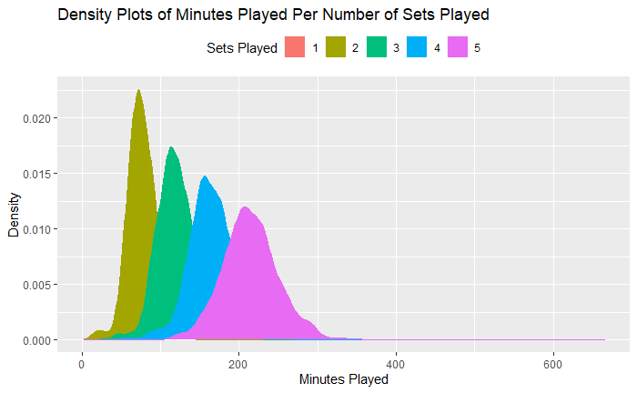

```r
ggplot(NewTable2) +
  aes(x = minutes, group = setsPlayed, fill = as.factor(setsPlayed), color = as.factor(setsPlayed)) +
  geom_density() +
  labs(title = "Density Plots of Minutes Played Per Number of Sets Played",
       x = "Minutes Played",
       y = "Density",
       fill = "Sets Played",
       color = "Sets Played") +
  theme(legend.position = "top")
```

This graph shows us how long a tennis match takes on average based on the number of sets played. There is no data for the first set because it has to be played out first to get a timing. OVerall though, you can see how the entire match takes longer and longer as there are more sets.